# BTVN Chương 5: Phân tích thành phần chính (PCA)

### Hệ số tương quan giữa thành phần chính và biến gốc (correlation loadings)

Trên ma trận tương quan ($s_{kk}=1$ với biến chuẩn hóa): $r_{\hat y_i,z_k}=\hat v_{ik}\sqrt{\hat\lambda_i}$.

```r
r_y_x <- matrix(0, p, 3, dimnames = list(colnames(X), paste0("y", 1:3)))
for (i in 1:3) {
  r_y_x[, i] <- V_hat[, i] * sqrt(lambda_hat[i])
}
bang(data.frame(Bien = colnames(X), round(r_y_x, 3), row.names = NULL), digits = 3)
```

| Bien | y1 | y2 | y3 |
| --- | --- | --- | --- |
| Points | 0.963 | 0.132 | -0.155 |
| Wins | 0.951 | 0.108 | -0.250 |
| Draws | -0.539 | 0.070 | 0.722 |
| Loses | -0.925 | -0.184 | -0.102 |
| Goals.scored | 0.930 | -0.341 | 0.013 |
| Goals.conceded | -0.796 | -0.521 | 0.071 |
| Difference.goals | 0.990 | 0.029 | -0.026 |
| Percentage.scored.goals | 0.931 | -0.340 | 0.011 |
| Percentage.conceded.goals | -0.797 | -0.521 | 0.072 |
| Shots | 0.788 | -0.464 | 0.151 |
| Shots.on.goal | 0.865 | -0.412 | 0.093 |
| Penalties.scored | 0.550 | -0.421 | -0.108 |
| Assistances | 0.933 | -0.288 | 0.017 |
| Fouls.made | -0.648 | -0.114 | -0.640 |
| Matches.without.conceding | 0.761 | 0.565 | -0.186 |
| Yellow.cards | -0.840 | -0.168 | -0.408 |
| Red.cards | -0.543 | -0.528 | -0.113 |
| Offsides | 0.559 | -0.529 | -0.064 |

Ví dụ thay số: $r_{\hat y_1,\text{Points}}=\hat v_{1,\text{Points}}\sqrt{\hat\lambda_1}=0.280\times\sqrt{11.815}=0.963$; $r_{\hat y_2,\text{Matches.without.conceding}}=0.364\times\sqrt{2.407}=0.565$; $r_{\hat y_3,\text{Draws}}=0.633\times\sqrt{1.300}=0.722$.

```r
# các biến tương quan mạnh nhất (trị tuyệt đối) với từng thành phần
for (i in 1:3) {
  thu_tu <- order(abs(r_y_x[, i]), decreasing = TRUE)[1:6]
  cat("y", i, ": ", paste0(rownames(r_y_x)[thu_tu], " (", sprintf("%.2f", r_y_x[thu_tu, i]), ")", collapse = ", "), "\n", sep = "")
}
```

```
## y1: Difference.goals (0.99), Points (0.96), Wins (0.95), Assistances (0.93), Percentage.scored.goals (0.93), Goals.scored (0.93)
## y2: Matches.without.conceding (0.56), Offsides (-0.53), Red.cards (-0.53), Goals.conceded (-0.52), Percentage.conceded.goals (-0.52), Shots (-0.46)
## y3: Draws (0.72), Fouls.made (-0.64), Yellow.cards (-0.41), Wins (-0.25), Matches.without.conceding (-0.19), Points (-0.16)
```

- **$\hat y_1$:** tương quan rất mạnh (|r| > 0.9) với `Difference.goals` (0.99), `Points` (0.96), `Wins` (0.95), `Goals.scored`, `Assistances`, và cùng độ lớn nhưng ngược dấu với `Loses` (-0.93); tương quan mạnh với `Shots.on.goal`, `Shots`, `Matches.without.conceding` (dương) và `Yellow.cards`, `Goals.conceded`, `Fouls.made` (âm). $\hat y_1$ **chủ yếu phụ thuộc vào nhóm biến kết quả – bàn thắng – tấn công**, đối lập với nhóm thua – bàn thua – phạm lỗi.
- **$\hat y_2$:** tương quan dương mạnh nhất với `Matches.without.conceding` (0.56) và âm với `Offsides` (-0.53), `Red.cards` (-0.53), `Goals.conceded` (-0.52), `Shots` (-0.46), `Penalties.scored`, `Shots.on.goal` — các tương quan ở mức trung bình (|r| khoảng 0.4–0.6). Trong khi đó `Points`, `Wins`, `Difference.goals` gần như không tương quan với $\hat y_2$.
- **$\hat y_3$:** tương quan dương mạnh với `Draws` (0.72), âm với `Fouls.made` (-0.64) và `Yellow.cards` (-0.41); các tương quan còn lại đều yếu.

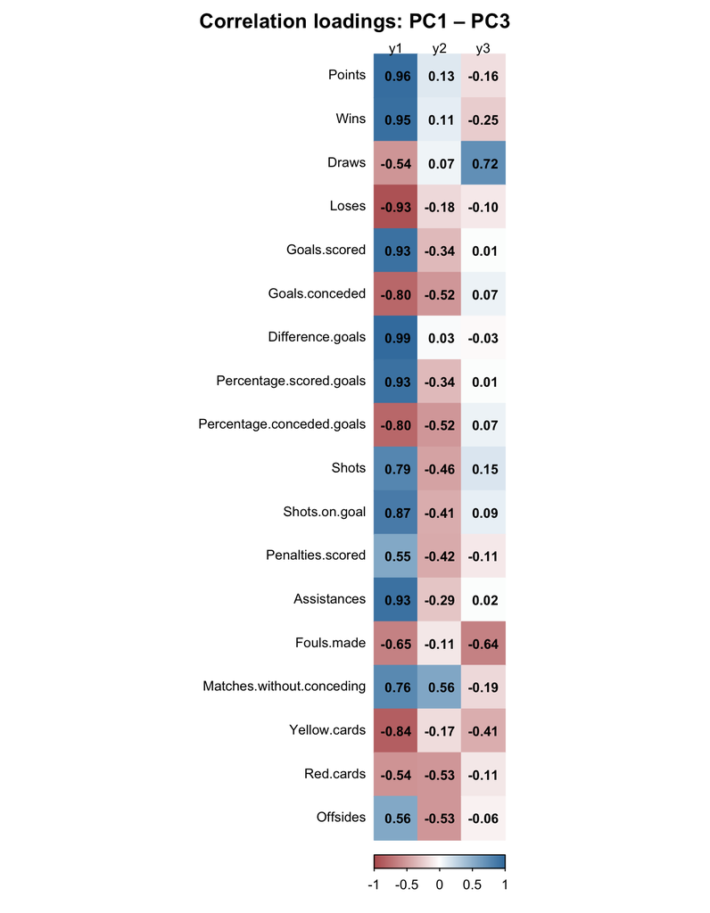

```r
corrplot::corrplot(r_y_x, is.corr = FALSE, method = "color", col.lim = c(-1, 1),
                   col = colorRampPalette(c("#B85C5C", "white", "#3F7EAD"))(200),
                   addCoef.col = "black", number.cex = 0.8, tl.col = "black", tl.cex = 0.8,
                   tl.srt = 0, cl.pos = "b", cl.ratio = 0.08, cl.cex = 0.8, cl.length = 5,
                   title = "Correlation loadings: PC1 – PC3", mar = c(0, 0, 2, 0))
```

Heatmap cho thấy rõ cột PC1 gần như toàn bộ là màu đậm (xanh với nhóm thành tích tốt, đỏ với nhóm thua – bàn thua – phạm lỗi), trong khi cột PC2 và PC3 chỉ đậm ở vài biến: PC2 ở `Matches.without.conceding` và nhóm bàn thua – thẻ đỏ – việt vị, PC3 ở `Draws` và `Fouls.made`.

### Đóng góp của từng biến vào thành phần chính (contribution)

Đóng góp của biến $z_k$ vào thành phần chính $\hat y_i$: $\text{Contribution}_{ik}=100\,\hat v_{ik}^2$ (%). Vì $\hat{\mathbf v}_i$ có độ dài 1 nên tổng contribution của các biến trong mỗi thành phần bằng 100%; nếu mọi biến đóng góp như nhau thì mỗi biến chiếm $100/p=$ 5.56%.

```r
contrib <- 100 * V_hat[, 1:3]^2
colnames(contrib) <- paste0("y", 1:3)
bang(data.frame(Bien = colnames(X), round(contrib, 2), row.names = NULL), digits = 2)
```

| Bien | y1 | y2 | y3 |
| --- | --- | --- | --- |
| Points | 7.85 | 0.72 | 1.86 |
| Wins | 7.66 | 0.49 | 4.79 |
| Draws | 2.46 | 0.20 | 40.05 |
| Loses | 7.24 | 1.40 | 0.81 |
| Goals.scored | 7.32 | 4.83 | 0.01 |
| Goals.conceded | 5.37 | 11.29 | 0.38 |
| Difference.goals | 8.30 | 0.04 | 0.05 |
| Percentage.scored.goals | 7.33 | 4.81 | 0.01 |
| Percentage.conceded.goals | 5.37 | 11.26 | 0.39 |
| Shots | 5.25 | 8.95 | 1.76 |
| Shots.on.goal | 6.34 | 7.04 | 0.67 |
| Penalties.scored | 2.56 | 7.37 | 0.90 |
| Assistances | 7.37 | 3.44 | 0.02 |
| Fouls.made | 3.56 | 0.54 | 31.52 |
| Matches.without.conceding | 4.91 | 13.25 | 2.67 |
| Yellow.cards | 5.98 | 1.17 | 12.81 |
| Red.cards | 2.49 | 11.57 | 0.98 |
| Offsides | 2.65 | 11.61 | 0.31 |

```r
colSums(contrib)
```

```
##  y1  y2  y3
## 100 100 100
```

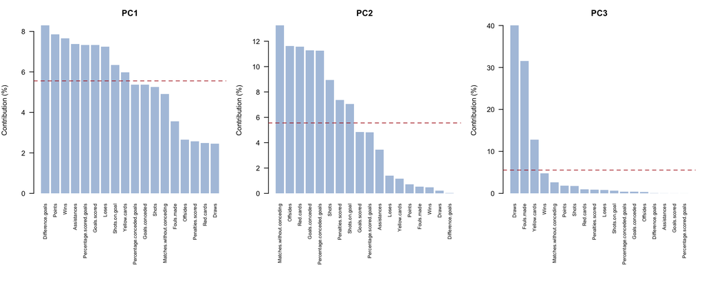

```r
par(mfrow = c(1, 3), mar = c(11, 4, 3, 1))
for (i in 1:3) {
  barplot(sort(contrib[, i], decreasing = TRUE), las = 2, cex.names = 0.7, col = "lightsteelblue",
          border = NA, ylab = "Contribution (%)", main = paste0("PC", i))
  abline(h = 100 / p, lty = 2, col = "firebrick")
}
```

```r
par(mfrow = c(1, 1))
```

Đường đỏ là mức trung bình 5.56%.

- **PC1:** 9 biến có contribution vượt mức trung bình, lớn nhất là `Difference.goals` (8.30%), `Points` (7.85%), `Wins` (7.66%) và chỉ cao hơn không nhiều so với các biến tiếp theo → PC1 được tạo nên từ **nhiều biến cùng lúc**, đúng với một thành phần tổng hợp.
- **PC2:** đóng góp lớn nhất từ `Matches.without.conceding` (13.25%), `Offsides`, `Red.cards`, `Goals.conceded`, `Percentage.conceded.goals` (mỗi biến khoảng 11%), tiếp theo là `Shots`, `Penalties.scored`, `Shots.on.goal`; các biến kết quả (`Points`, `Wins`, `Difference.goals`) đóng góp gần 0.
- **PC3:** gần như chỉ do hai biến `Draws` (40.05%) và `Fouls.made` (31.52%), cộng thêm `Yellow.cards` (12.81%) — ba biến chiếm 84% của PC3.

### Chất lượng biểu diễn của từng biến (cos²)

Chất lượng biểu diễn của biến $z_k$ trên thành phần $\hat y_i$ là bình phương hệ số tương quan: $\cos^2_{ik}=r^2_{\hat y_i,z_k}=\hat\lambda_i\hat v_{ik}^2$, tức tỷ lệ phương sai của $z_k$ được giải thích bởi $\hat y_i$. Tổng qua các thành phần giữ lại $Q_k=\sum_{i=1}^{3}\cos^2_{ik}$ cho biết phần phương sai của biến $z_k$ được biểu diễn trong không gian ba thành phần đầu (tổng qua tất cả $p$ thành phần bằng 1).

```r
r2 <- r_y_x^2
bang(data.frame(Bien = colnames(X), round(r2, 3),
                Q_3_TPC = round(rowSums(r2), 3), row.names = NULL), digits = 3)
```

| Bien | y1 | y2 | y3 | Q_3_TPC |
| --- | --- | --- | --- | --- |
| Points | 0.927 | 0.017 | 0.024 | 0.969 |
| Wins | 0.905 | 0.012 | 0.062 | 0.979 |
| Draws | 0.290 | 0.005 | 0.521 | 0.816 |
| Loses | 0.856 | 0.034 | 0.010 | 0.900 |
| Goals.scored | 0.865 | 0.116 | 0.000 | 0.982 |
| Goals.conceded | 0.634 | 0.272 | 0.005 | 0.911 |
| Difference.goals | 0.981 | 0.001 | 0.001 | 0.982 |
| Percentage.scored.goals | 0.866 | 0.116 | 0.000 | 0.982 |
| Percentage.conceded.goals | 0.635 | 0.271 | 0.005 | 0.911 |
| Shots | 0.621 | 0.215 | 0.023 | 0.859 |
| Shots.on.goal | 0.749 | 0.170 | 0.009 | 0.927 |
| Penalties.scored | 0.303 | 0.177 | 0.012 | 0.492 |
| Assistances | 0.871 | 0.083 | 0.000 | 0.954 |
| Fouls.made | 0.420 | 0.013 | 0.410 | 0.843 |
| Matches.without.conceding | 0.580 | 0.319 | 0.035 | 0.933 |
| Yellow.cards | 0.706 | 0.028 | 0.167 | 0.901 |
| Red.cards | 0.294 | 0.278 | 0.013 | 0.585 |
| Offsides | 0.313 | 0.280 | 0.004 | 0.596 |

- PC1 biểu diễn rất tốt (cos² > 0.85) `Difference.goals`, `Points`, `Wins`, `Goals.scored`, `Assistances`, `Loses` — các biến kết quả và tấn công.
- PC2 biểu diễn phần lớn nhất của `Offsides`, `Red.cards`, `Matches.without.conceding`, `Goals.conceded` (cos² khoảng 0.27–0.32), PC3 biểu diễn phần lớn của `Draws` (0.52) và `Fouls.made` (0.41).

Xét tổng $Q_k$: ba thành phần đầu giải thích từ 49% (Penalties.scored) đến 98% (Difference.goals) phương sai của từng biến. Các biến được biểu diễn kém nhất là Penalties.scored và Red.cards: phần lớn biến thiên của chúng nằm ở các thành phần sau.

### So sánh hai kịch bản (18 và 16 biến)

Thực hiện PCA trên ma trận tương quan của 16 biến theo cùng cách, rồi đặt kết quả cạnh kịch bản 18 biến.

```r
eig16 <- eigen(cor(X16))
lambda16 <- eig16$values
V16 <- eig16$vectors
rownames(V16) <- colnames(X16)
if (V16["Points", 1] < 0) V16[, 1] <- -V16[, 1]
if (V16["Matches.without.conceding", 2] < 0) V16[, 2] <- -V16[, 2]
if (V16["Draws", 3] < 0) V16[, 3] <- -V16[, 3]

bang(data.frame(TPC = paste0("y", 1:6),
                lambda_18 = round(lambda_hat[1:6], 3),
                lambda_16 = round(lambda16[1:6], 3)), digits = 3)
```

| TPC | lambda_18 | lambda_16 |
| --- | --- | --- |
| y1 | 11.815 | 10.320 |
| y2 | 2.407 | 2.042 |
| y3 | 1.300 | 1.294 |
| y4 | 0.837 | 0.800 |
| y5 | 0.736 | 0.725 |
| y6 | 0.364 | 0.297 |

```r
c(so_lambda_gan_0_18 = sum(lambda_hat < 1e-3), so_lambda_gan_0_16 = sum(lambda16 < 1e-3))
```

```
## so_lambda_gan_0_18 so_lambda_gan_0_16
##                  5                  3
```

Bỏ hai biến tỷ lệ phần trăm làm $\hat\lambda_1$ giảm từ 11.815 xuống 10.32, còn $\hat\lambda_2,\hat\lambda_3$ thay đổi ít. Số trị riêng gần 0 giảm từ 5 xuống 3 vì hai quan hệ “gần tỷ lệ thuận” đã bị loại; ba quan hệ tuyến tính chính xác (`Points`, `Loses`, `Difference.goals`) vẫn còn.

```r
chung <- colnames(X16)
r16 <- matrix(0, p16, 3, dimnames = list(chung, paste0("y", 1:3, "_16")))
for (i in 1:3) {
  r16[, i] <- V16[, i] * sqrt(lambda16[i])
}
r18 <- r_y_x[chung, ]
colnames(r18) <- paste0("y", 1:3, "_18")
bang(data.frame(Bien = chung, round(r18, 2), round(r16, 2), row.names = NULL), digits = 2)
```

| Bien | y1_18 | y2_18 | y3_18 | y1_16 | y2_16 | y3_16 |
| --- | --- | --- | --- | --- | --- | --- |
| Points | 0.96 | 0.13 | -0.16 | 0.96 | 0.13 | -0.17 |
| Wins | 0.95 | 0.11 | -0.25 | 0.95 | 0.11 | -0.26 |
| Draws | -0.54 | 0.07 | 0.72 | -0.54 | 0.07 | 0.73 |
| Loses | -0.93 | -0.18 | -0.10 | -0.92 | -0.18 | -0.09 |
| Goals.scored | 0.93 | -0.34 | 0.01 | 0.93 | -0.32 | 0.02 |
| Goals.conceded | -0.80 | -0.52 | 0.07 | -0.78 | -0.49 | 0.09 |
| Difference.goals | 0.99 | 0.03 | -0.03 | 0.99 | 0.03 | -0.03 |
| Shots | 0.79 | -0.46 | 0.15 | 0.79 | -0.45 | 0.17 |
| Shots.on.goal | 0.87 | -0.41 | 0.09 | 0.87 | -0.40 | 0.11 |
| Penalties.scored | 0.55 | -0.42 | -0.11 | 0.55 | -0.42 | -0.09 |
| Assistances | 0.93 | -0.29 | 0.02 | 0.94 | -0.26 | 0.02 |
| Fouls.made | -0.65 | -0.11 | -0.64 | -0.65 | -0.17 | -0.62 |
| Matches.without.conceding | 0.76 | 0.56 | -0.19 | 0.76 | 0.55 | -0.21 |
| Yellow.cards | -0.84 | -0.17 | -0.41 | -0.84 | -0.20 | -0.39 |
| Red.cards | -0.54 | -0.53 | -0.11 | -0.54 | -0.59 | -0.06 |
| Offsides | 0.56 | -0.53 | -0.06 | 0.57 | -0.56 | -0.03 |

```r
round(apply(abs(r18 - r16), 2, max), 3)
```

```
## y1_18 y2_18 y3_18
## 0.012 0.064 0.049
```

```r
# độ tương đồng về hướng của PC1–PC3 trên 16 biến chung (cosin góc giữa hai vectơ hệ số)
tuong_dong <- numeric(3)
for (i in 1:3) {
  a <- V_hat[chung, i]
  b <- V16[chung, i]
  tuong_dong[i] <- abs(sum(a * b)) / sqrt(sum(a^2) * sum(b^2))
}
round(tuong_dong, 4)
```

```
## [1] 1.0000 0.9970 0.9975
```

Hệ số tương quan của từng biến với PC1–PC3 ở hai kịch bản gần như trùng nhau (chênh lệch lớn nhất theo từng thành phần: 0.012, 0.064, 0.049), độ tương đồng về hướng của PC1, PC2, PC3 lần lượt là 1.000, 0.997, 0.997 → ba thành phần chính đầu **gần như không đổi** khi bỏ hai biến tỷ lệ phần trăm.

```r
contrib16 <- 100 * V16[, 1:3]^2
colnames(contrib16) <- paste0("Contrib_y", 1:3, "_16")
contrib18 <- contrib[chung, ]
colnames(contrib18) <- paste0("Contrib_y", 1:3, "_18")
bang(data.frame(Bien = chung, round(contrib18, 2), round(contrib16, 2), row.names = NULL), digits = 2)
```

| Bien | Contrib_y1_18 | Contrib_y2_18 | Contrib_y3_18 | Contrib_y1_16 | Contrib_y2_16 | Contrib_y3_16 |
| --- | --- | --- | --- | --- | --- | --- |
| Points | 7.85 | 0.72 | 1.86 | 8.97 | 0.85 | 2.12 |
| Wins | 7.66 | 0.49 | 4.79 | 8.75 | 0.58 | 5.25 |
| Draws | 2.46 | 0.20 | 40.05 | 2.81 | 0.21 | 41.54 |
| Loses | 7.24 | 1.40 | 0.81 | 8.27 | 1.63 | 0.70 |
| Goals.scored | 7.32 | 4.83 | 0.01 | 8.44 | 4.95 | 0.03 |
| Goals.conceded | 5.37 | 11.29 | 0.38 | 5.96 | 11.62 | 0.58 |
| Difference.goals | 8.30 | 0.04 | 0.05 | 9.43 | 0.04 | 0.06 |
| Shots | 5.25 | 8.95 | 1.76 | 6.09 | 9.94 | 2.24 |
| Shots.on.goal | 6.34 | 7.04 | 0.67 | 7.35 | 7.69 | 0.90 |
| Penalties.scored | 2.56 | 7.37 | 0.90 | 2.94 | 8.58 | 0.66 |
| Assistances | 7.37 | 3.44 | 0.02 | 8.53 | 3.33 | 0.03 |
| Fouls.made | 3.56 | 0.54 | 31.52 | 4.12 | 1.45 | 29.92 |
| Matches.without.conceding | 4.91 | 13.25 | 2.67 | 5.54 | 14.87 | 3.54 |
| Yellow.cards | 5.98 | 1.17 | 12.81 | 6.84 | 1.92 | 12.05 |
| Red.cards | 2.49 | 11.57 | 0.98 | 2.85 | 17.14 | 0.31 |
| Offsides | 2.65 | 11.61 | 0.31 | 3.10 | 15.19 | 0.06 |

```r
Q16 <- rowSums(r16^2)
bang(data.frame(Bien = chung, Q_18 = round(rowSums(r2[chung, ]), 3), Q_16 = round(Q16, 3),
                row.names = NULL), digits = 3)
```

| Bien | Q_18 | Q_16 |
| --- | --- | --- |
| Points | 0.969 | 0.971 |
| Wins | 0.979 | 0.983 |
| Draws | 0.816 | 0.832 |
| Loses | 0.900 | 0.896 |
| Goals.scored | 0.982 | 0.973 |
| Goals.conceded | 0.911 | 0.860 |
| Difference.goals | 0.982 | 0.975 |
| Shots | 0.859 | 0.860 |
| Shots.on.goal | 0.927 | 0.927 |
| Penalties.scored | 0.492 | 0.488 |
| Assistances | 0.954 | 0.949 |
| Fouls.made | 0.843 | 0.842 |
| Matches.without.conceding | 0.933 | 0.921 |
| Yellow.cards | 0.901 | 0.901 |
| Red.cards | 0.585 | 0.648 |
| Offsides | 0.596 | 0.631 |

### Ma trận hệ số tải và các đồ thị

#### Barplot hệ số tải

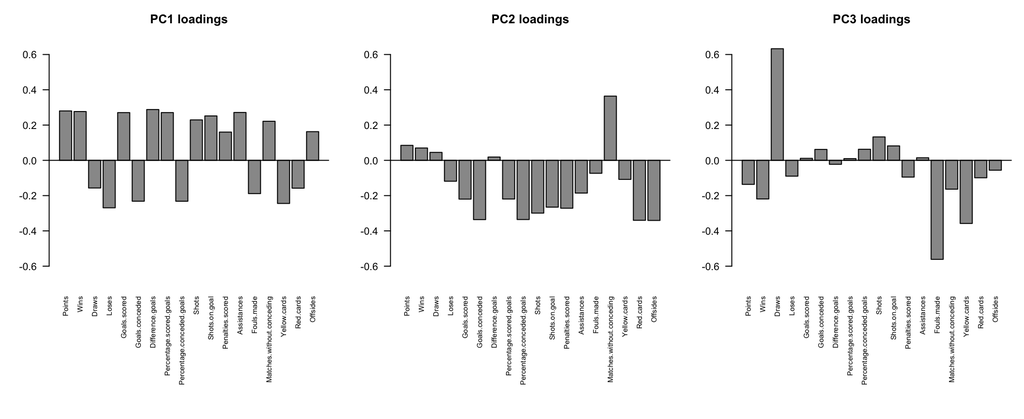

```r
par(mfrow = c(1, 3), mar = c(11, 4, 3, 1))
for (i in 1:3) {
  barplot(V_hat[, i], las = 2, col = "grey60", ylim = c(-0.7, 0.7), cex.names = 0.7,
          main = paste0("PC", i, " loadings"))
  abline(h = 0)
}
```

```r
par(mfrow = c(1, 1))
```

- **PC1:** các cột tách thành hai phía rõ rệt, độ lớn khá đều nhau (≈ 0.15–0.29): phía dương là thắng, điểm, bàn thắng, sút, kiến tạo, giữ sạch lưới; phía âm là thua, bàn thua, phạm lỗi, thẻ vàng, thẻ đỏ và cả `Draws`.
- **PC2:** cột dương nổi bật là `Matches.without.conceding`; phía âm là `Offsides`, `Red.cards`, `Goals.conceded`, `Shots`, `Penalties.scored` — các biến điểm số gần 0.
- **PC3:** nổi bật `Draws` (dương) đối lập `Fouls.made`, `Yellow.cards` (âm).

#### Đồ thị loading và vòng tròn tương quan

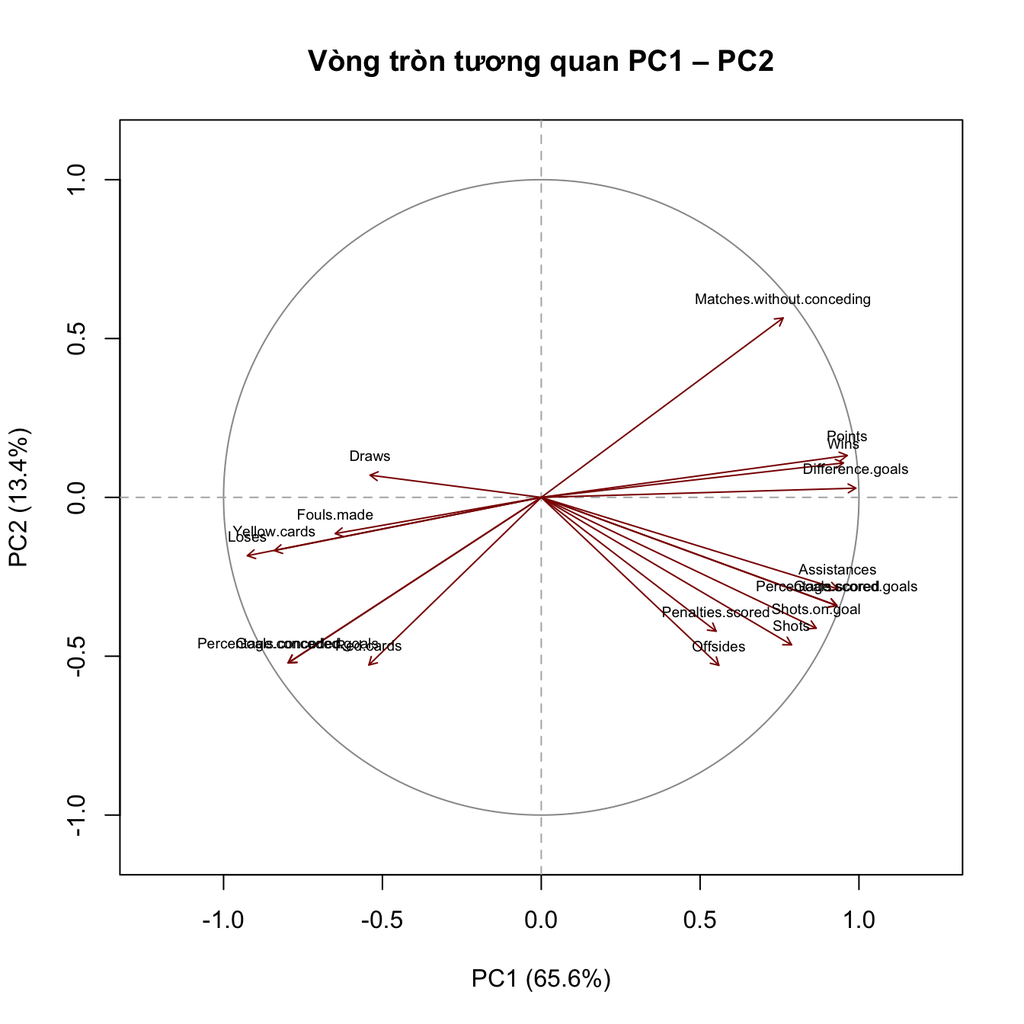

```r
plot(NA, xlim = c(-1.1, 1.1), ylim = c(-1.1, 1.1), asp = 1,
     xlab = paste0("PC1 (", round(100 * lambda_hat[1] / p, 1), "%)"),
     ylab = paste0("PC2 (", round(100 * lambda_hat[2] / p, 1), "%)"),
     main = "Vòng tròn tương quan PC1 – PC2")
symbols(0, 0, circles = 1, inches = FALSE, add = TRUE, fg = "grey60")
abline(h = 0, v = 0, lty = 2, col = "grey70")
arrows(0, 0, r_y_x[, 1], r_y_x[, 2], length = 0.06, col = "darkred")
text(r_y_x[, 1], r_y_x[, 2], labels = colnames(X), cex = 0.6, pos = 3)
```

Mỗi mũi tên là một biến, tọa độ là tương quan của biến với PC1 và PC2. Mũi tên càng gần vòng tròn thì biến càng được hai thành phần đầu biểu diễn tốt.

- Các biến kết quả (`Points`, `Wins`, `Difference.goals`) nằm sát trục PC1 phía dương và gần vòng tròn; `Loses` nằm đối xứng phía âm → PC1 gần như là trục kết quả thi đấu.
- `Goals.scored`, `Shots`, `Assistances` lệch xuống dưới (PC2 âm), `Matches.without.conceding` lệch lên trên (PC2 dương): hai nhóm “tấn công” và “phòng ngự” của đội mạnh tách nhau theo PC2.
- `Goals.conceded`, `Red.cards`, `Offsides` cùng nằm phía PC2 âm.

#### Đồ thị score

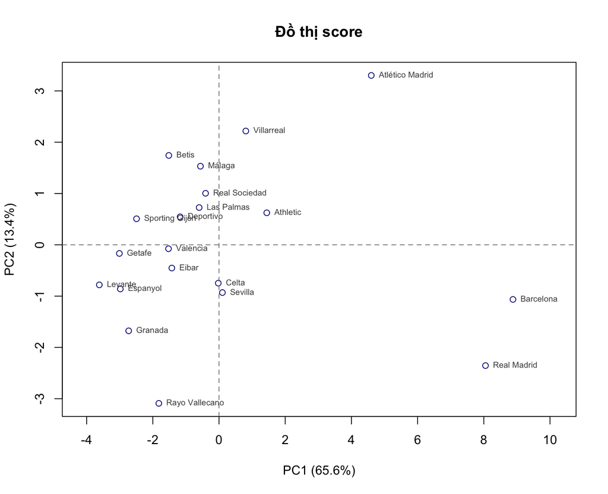

```r
plot(Y_hat[, 1], Y_hat[, 2], pch = 1, col = "navy",
     xlab = paste0("PC1 (", round(100 * lambda_hat[1] / p, 1), "%)"),
     ylab = paste0("PC2 (", round(100 * lambda_hat[2] / p, 1), "%)"),
     main = "Đồ thị score", xlim = range(Y_hat[, 1]) * 1.15)
text(Y_hat[, 1], Y_hat[, 2], labels = rownames(X), pos = 4, cex = 0.65, col = "grey30")
abline(h = 0, v = 0, lty = 2, col = "grey50")
```

```r
# thứ hạng theo điểm số so với score PC1
data.frame(Doi = rownames(X), Points = laliga$Points,
           y1 = round(Y_hat[, 1], 2), y2 = round(Y_hat[, 2], 2), row.names = NULL)
```

```
##                Doi Points    y1    y2
## 1        Barcelona     91  8.88 -1.06
## 2      Real Madrid     90  8.05 -2.35
## 3  Atlético Madrid     88  4.60  3.30
## 4       Villarreal     64  0.81  2.22
## 5         Athletic     62  1.44  0.62
## 6            Celta     60 -0.02 -0.75
## 7          Sevilla     52  0.10 -0.93
## 8           Málaga     48 -0.56  1.53
## 9    Real Sociedad     48 -0.41  1.00
## 10           Betis     45 -1.52  1.74
## 11      Las Palmas     44 -0.60  0.73
## 12        Valencia     44 -1.53 -0.08
## 13           Eibar     43 -1.43 -0.45
## 14        Espanyol     43 -2.98 -0.86
## 15       Deportivo     42 -1.18  0.55
## 16         Granada     39 -2.73 -1.68
## 17  Sporting Gijón     39 -2.49  0.51
## 18  Rayo Vallecano     38 -1.82 -3.09
## 19          Getafe     36 -3.01 -0.17
## 20         Levante     32 -3.62 -0.78
```

```r
cor(laliga$Points, Y_hat[, 1])
```

```
## [1] 0.9630595
```

- **Theo PC1:** Barcelona, Real Madrid, Atlético Madrid nằm tách xa về phía dương, phần lớn các đội còn lại tụ ở phía âm gần nhau. Tương quan giữa score PC1 và số điểm cuối mùa là 0.963 → thứ tự trên trục PC1 gần như trùng với bảng xếp hạng.
- **Theo PC2:** Atlético Madrid có score PC2 cao nhất (đội giữ sạch lưới 24 trận, ít bàn thua); các đội nằm thấp nhất theo PC2 là Rayo Vallecano và Real Madrid.

#### 95% mật độ ellipsoid và các thành phần chính

Nếu ${\mathbf x}$ có phân phối chuẩn nhiều chiều thì $(\hat y_1,\hat y_2)$ xấp xỉ chuẩn với trung bình 0, không tương quan, phương sai $\hat\lambda_1,\hat\lambda_2$. Ellipse mật độ 95% trên mặt phẳng PC1–PC2 là tập các điểm thỏa

$$\frac{\hat
y_1^2}{\hat\lambda_1}+\frac{\hat
y_2^2}{\hat\lambda_2}\le\chi^2_2(0.95),$$

có tâm tại gốc, trục lớn theo hướng PC1 với nửa độ dài $\sqrt{\chi^2_2(0.95)\,\hat\lambda_1}$, trục nhỏ theo hướng PC2 với nửa độ dài $\sqrt{\chi^2_2(0.95)\,\hat\lambda_2}$. Hai mũi tên trên đồ thị là hai thành phần chính (hai trục của ellipse).

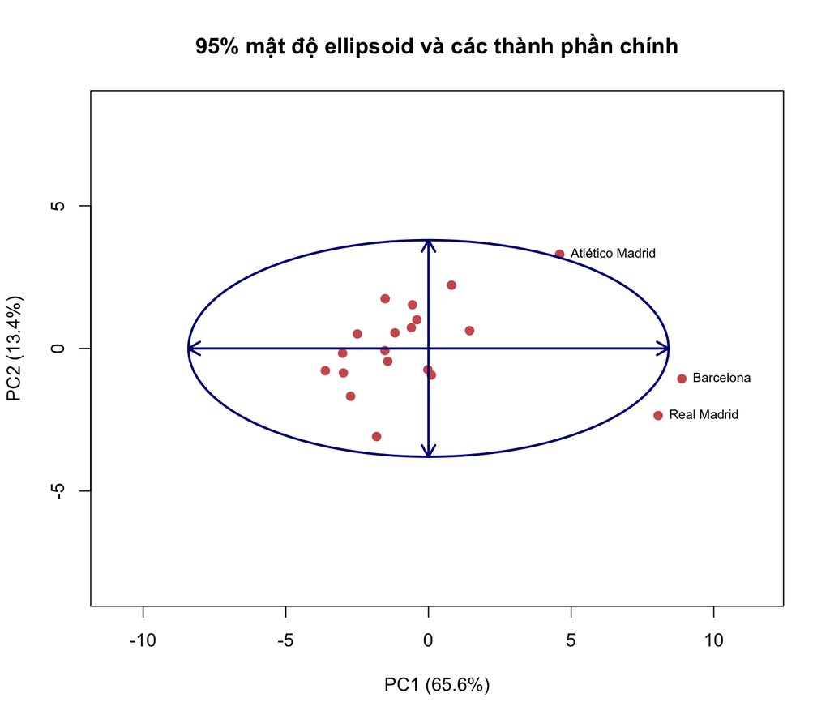

```r
chi2_95 <- qchisq(0.95, df = 2)
nua_truc_1 <- sqrt(chi2_95 * lambda_hat[1])
nua_truc_2 <- sqrt(chi2_95 * lambda_hat[2])
goc <- seq(0, 2 * pi, length.out = 300)

plot(Y_hat[, 1], Y_hat[, 2], pch = 19, col = "indianred", asp = 1,
     xlim = range(c(Y_hat[, 1], -nua_truc_1, nua_truc_1)) * 1.3,
     ylim = range(c(Y_hat[, 2], -nua_truc_2, nua_truc_2)) * 1.1,
     xlab = paste0("PC1 (", round(100 * lambda_hat[1] / sum(lambda_hat), 1), "%)"),
     ylab = paste0("PC2 (", round(100 * lambda_hat[2] / sum(lambda_hat), 1), "%)"),
     main = "95% mật độ ellipsoid và các thành phần chính")
lines(nua_truc_1 * cos(goc), nua_truc_2 * sin(goc), lwd = 2, col = "navy")
arrows(-nua_truc_1, 0, nua_truc_1, 0, code = 3, length = 0.12, lwd = 2, col = "navy")
arrows(0, -nua_truc_2, 0, nua_truc_2, code = 3, length = 0.12, lwd = 2, col = "navy")

# các đội nằm ngoài ellipse 95%
d2_pc <- Y_hat[, 1]^2 / lambda_hat[1] + Y_hat[, 2]^2 / lambda_hat[2]
ngoai <- which(d2_pc > chi2_95)
text(Y_hat[ngoai, 1], Y_hat[ngoai, 2], labels = rownames(X)[ngoai], pos = 4, cex = 0.7)
```

```r
c(nua_truc_1 = nua_truc_1, nua_truc_2 = nua_truc_2)
```

```
## nua_truc_1 nua_truc_2
##   8.413587   3.797447
```

```r
c(so_ngoai_ellipse = length(ngoai), ky_vong = 0.05 * n)
```

```
## so_ngoai_ellipse          ky_vong
##                3                1
```

```r
rownames(X)[ngoai]
```

```
## [1] "Barcelona"       "Real Madrid"     "Atlético Madrid"
```

Ellipse có tâm tại gốc (điểm trung bình), trục lớn nằm theo hướng PC1 với nửa độ dài 8.4136 và trục nhỏ theo hướng PC2 với nửa độ dài 3.7974; tỷ số hai trục $\sqrt{\hat\lambda_1/\hat\lambda_2}=$ 2.22 cho thấy dữ liệu trải rộng theo PC1 nhiều hơn theo PC2. Có 3 đội nằm ngoài ellipse (Barcelona, Real Madrid, Atlético Madrid), so với khoảng 1 đội kỳ vọng nếu dữ liệu chuẩn. Với n = 20, ellipse chỉ là mốc tham khảo (bài không giả định chuẩn); các đội nằm ngoài là những đội có thành tích hoặc phong cách thi đấu khác biệt rõ so với phần còn lại của giải.

#### Biplot

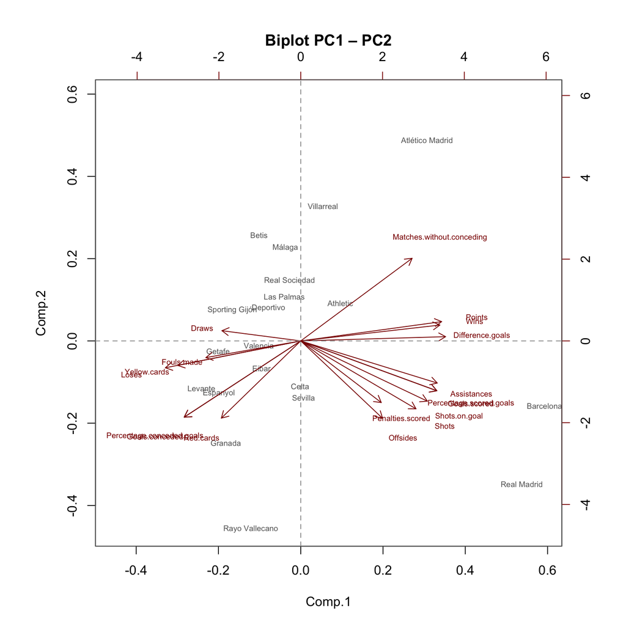

```r
pc_laliga <- princomp(X, cor = TRUE)
biplot(pc_laliga, choices = 1:2, col = c("grey40", "darkred"), cex = c(0.6, 0.6),
       expand = 0.9, main = "Biplot PC1 – PC2")
abline(h = 0, v = 0, lty = 2, col = "grey60")
```

Biplot vẽ chồng các đội (tên) và các biến (mũi tên). (Hướng của trục có thể đảo so với các đồ thị trên vì vectơ riêng xác định đến dấu.) Các đội nằm theo hướng của nhóm mũi tên thắng – điểm – bàn thắng là các đội đứng đầu; các đội nằm theo hướng mũi tên thua – bàn thua – thẻ phạt là các đội cuối bảng. Góc giữa hai mũi tên càng nhỏ thì hai biến tương quan càng mạnh (xấp xỉ): `Points`, `Wins`, `Difference.goals` gần như trùng hướng, ngược hẳn với `Loses`.

**Kết luận câu (a):** PCA được thực hiện trên ma trận tương quan của p = 18 biến thành tích (đã loại `Matches`), cho các trị riêng $\hat\lambda_1=$ 11.815, $\hat\lambda_2=$ 2.407, $\hat\lambda_3=$ 1.3, … (5 trị riêng gần 0 do các biến phụ thuộc tuyến tính). Thành phần chính thứ nhất gắn chặt với kết quả thi đấu và hiệu quả tấn công, thành phần thứ hai với khả năng giữ sạch lưới đối lập với bàn thua – thẻ đỏ – việt vị, thành phần thứ ba với số trận hòa đối lập với phạm lỗi – thẻ vàng.

## Câu (b) — Số thành phần chính cần giữ lại

### Tỷ số đóng góp vào phương sai suy rộng

Trên ma trận tương quan, phương sai suy rộng $=\text{tr}(\mathbf R)=p=18$; tỷ số đóng góp của thành phần thứ $i$ là $\hat\lambda_i/p$, tỷ lệ tích lũy $r_q=\sum_{k=1}^q\hat\lambda_k/p$.

```r
ty_le <- lambda_hat / p
ty_le_tich_luy <- cumsum(lambda_hat) / p
bang(data.frame(TPC = paste0("y", 1:8),
                lambda_hat = round(lambda_hat[1:8], 4),
                Ty_le_phan_tram = round(100 * ty_le[1:8], 2),
                Tich_luy_phan_tram = round(100 * ty_le_tich_luy[1:8], 2)), digits = 4)
```

| TPC | lambda_hat | Ty_le_phan_tram | Tich_luy_phan_tram |
| --- | --- | --- | --- |
| y1 | 11.8149 | 65.64 | 65.64 |
| y2 | 2.4069 | 13.37 | 79.01 |
| y3 | 1.3001 | 7.22 | 86.23 |
| y4 | 0.8368 | 4.65 | 90.88 |
| y5 | 0.7362 | 4.09 | 94.97 |
| y6 | 0.3636 | 2.02 | 96.99 |
| y7 | 0.2096 | 1.16 | 98.16 |
| y8 | 0.1397 | 0.78 | 98.93 |

$\hat y_1$ giải thích 65.64% phương sai suy rộng; hai thành phần đầu 79.01%; ba thành phần đầu 86.23%; bốn thành phần đầu 90.88%.

### Scree-plot

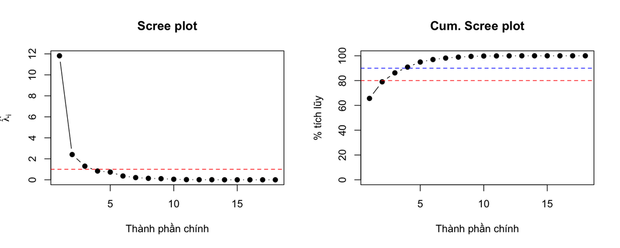

```r
par(mfrow = c(1, 2))
plot(1:p, lambda_hat, type = "b", pch = 19, xlab = "Thành phần chính",
     ylab = expression(hat(lambda)[i]), main = "Scree plot")
abline(h = 1, col = "red", lty = 2)
plot(1:p, 100 * ty_le_tich_luy, type = "b", pch = 19, ylim = c(0, 100),
     xlab = "Thành phần chính", ylab = "% tích lũy", main = "Cum. Scree plot")
abline(h = c(80, 90), col = c("red", "blue"), lty = 2)
```

```r
par(mfrow = c(1, 1))
```

Trị riêng giảm rất mạnh từ $\hat\lambda_1$ xuống $\hat\lambda_2$, giảm tiếp đến $\hat\lambda_3$, rồi từ $\hat\lambda_4$ trở đi các trị riêng nhỏ (dưới 1) và giảm chậm, gần như nằm ngang. Đường đỏ ở mức 1 chỉ có ba trị riêng đầu nằm trên.

### Lựa chọn số thành phần

```r
c(dat_70 = which(ty_le_tich_luy >= 0.70)[1],
  dat_80 = which(ty_le_tich_luy >= 0.80)[1],
  dat_90 = which(ty_le_tich_luy >= 0.90)[1],
  Kaiser = sum(lambda_hat > 1))
```

```
## dat_70 dat_80 dat_90 Kaiser
##      2      3      4      3
```

1. **Tỷ lệ phương sai tích lũy:** cần 2 thành phần để đạt 70%, 3 thành phần để đạt 80% (hai thành phần đầu chỉ đạt 79.01%, chưa tới ngưỡng) và 4 thành phần để đạt 90%.
2. **Scree-plot:** đoạn dốc kết thúc ở thành phần thứ 3, sau đó đường gần như nằm ngang → giữ 3 thành phần.
3. **Tiêu chuẩn Kaiser** (PCA trên R, giữ $\hat\lambda_q>1$): có 3 trị riêng lớn hơn 1 → giữ 3 thành phần.

Ba tiêu chí cùng cho kết quả **giữ 3 thành phần chính**, giải thích 86.23% phương sai suy rộng. Thành phần thứ tư ($\hat\lambda_4=$ 0.837 < 1) chỉ thêm 4.65%.

### So sánh hai kịch bản (18 và 16 biến)

```r
tl16 <- lambda16 / p16
tlt16 <- cumsum(lambda16) / p16
bang(data.frame(
  Chi_tieu = c("% PC1", "% PC2", "% PC3", "% tích lũy PC1–PC2", "% tích lũy PC1–PC3",
               "Số TPC có lambda > 1", "Số TPC đạt 80%", "Số TPC đạt 90%"),
  Kich_ban_18 = c(round(100 * ty_le[1:3], 2), round(100 * ty_le_tich_luy[2:3], 2),
                  sum(lambda_hat > 1), which(ty_le_tich_luy >= 0.8)[1], which(ty_le_tich_luy >= 0.9)[1]),
  Kich_ban_16 = c(round(100 * tl16[1:3], 2), round(100 * tlt16[2:3], 2),
                  sum(lambda16 > 1), which(tlt16 >= 0.8)[1], which(tlt16 >= 0.9)[1])
), digits = 2)
```

| Chi_tieu | Kich_ban_18 | Kich_ban_16 |
| --- | --- | --- |
| % PC1 | 65.64 | 64.50 |
| % PC2 | 13.37 | 12.77 |
| % PC3 | 7.22 | 8.09 |
| % tích lũy PC1–PC2 | 79.01 | 77.27 |
| % tích lũy PC1–PC3 | 86.23 | 85.35 |
| Số TPC có lambda > 1 | 3.00 | 3.00 |
| Số TPC đạt 80% | 3.00 | 3.00 |
| Số TPC đạt 90% | 4.00 | 4.00 |

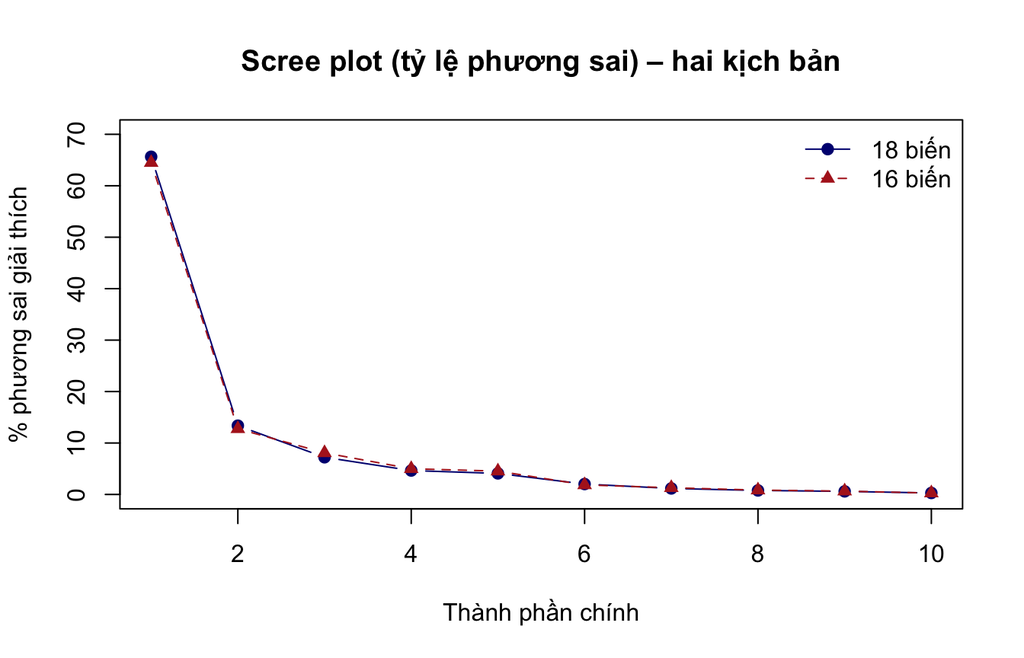

```r
plot(1:10, 100 * ty_le[1:10], type = "b", pch = 19, col = "navy", ylim = c(0, 70),
     xlab = "Thành phần chính", ylab = "% phương sai giải thích",
     main = "Scree plot (tỷ lệ phương sai) – hai kịch bản")
lines(1:10, 100 * tl16[1:10], type = "b", pch = 17, lty = 2, col = "firebrick")
legend("topright", bty = "n", legend = c("18 biến", "16 biến"),
       col = c("navy", "firebrick"), pch = c(19, 17), lty = c(1, 2))
```

Hai đường scree gần như trùng nhau, cùng có khuỷu tay ở thành phần thứ 3. Kịch bản 16 biến có tỷ lệ của PC1 thấp hơn một chút (64.5% so với 65.64%) — ở kịch bản 18 biến, thông tin số bàn thắng/bàn thua bị tính hai lần nên PC1 (nơi các biến này có hệ số lớn) được “thổi phồng” nhẹ. Cả hai kịch bản đều có 3 trị riêng lớn hơn 1 và cần 3 thành phần để vượt 80% → **cùng kết luận giữ 3 thành phần**, giải thích 86.23% (18 biến) và 85.35% (16 biến).

**Kết luận câu (b):** Giữ lại **3 thành phần chính đầu tiên**: chúng giải thích 86.23% tổng phương sai của 18 biến (vượt ngưỡng 80%), là ba thành phần duy nhất có trị riêng lớn hơn 1 và nằm trên đoạn dốc của scree plot. Như vậy 18 biến thống kê có thể thu gọn xuống 3 chiều mà vẫn giữ được khoảng 86% thông tin.

## Câu (c) — Ý nghĩa của các thành phần chính được giữ lại

```r
bang(data.frame(TPC = paste0("y", 1:3),
                lambda_hat = round(lambda_hat[1:3], 3),
                Ty_le_phan_tram = round(100 * ty_le[1:3], 2),
                Tich_luy_phan_tram = round(100 * ty_le_tich_luy[1:3], 2)), digits = 3)
```

| TPC | lambda_hat | Ty_le_phan_tram | Tich_luy_phan_tram |
| --- | --- | --- | --- |
| y1 | 11.815 | 65.64 | 65.64 |
| y2 | 2.407 | 13.37 | 79.01 |
| y3 | 1.300 | 7.22 | 86.23 |

### Thành phần chính thứ nhất — sức mạnh tổng thể của đội

$\hat y_1$ giải thích 65.64% phương sai, gấp gần 5 lần thành phần thứ hai. Hệ số của $\hat y_1$ có độ lớn khá đều trên gần như mọi biến, chia thành hai nhóm ngược dấu:

- **Nhóm dương:** `Difference.goals`, `Points`, `Wins`, `Goals.scored`, `Percentage.scored.goals`, `Assistances`, `Shots.on.goal`, `Shots`, `Matches.without.conceding` — thắng nhiều, ghi nhiều bàn, tấn công tốt và phòng ngự chắc.
- **Nhóm âm:** `Loses`, `Yellow.cards`, `Goals.conceded`, `Percentage.conceded.goals`, `Fouls.made`, và ở mức yếu hơn `Draws`, `Red.cards`.

$\hat y_1$ vì vậy là **thành phần “sức mạnh tổng thể” (chất lượng đội bóng)**. Đội có điểm $\hat y_1$ cao có xu hướng thắng nhiều, ghi nhiều bàn, sút và kiến tạo nhiều, thua ít bàn và ít phạm lỗi, ít thẻ; đội có điểm thấp thì ngược lại. Score PC1 tương quan 0.963 với số điểm cuối mùa: Barcelona, Real Madrid, Atlético Madrid có score cao nhất, Levante thấp nhất. Việc các đội phạm lỗi và nhận thẻ nhiều hơn nằm cùng phía với đội thua nhiều cho thấy các đội yếu thường phải phòng ngự nhiều hơn và phạm lỗi nhiều hơn.

### Thành phần chính thứ hai — phong cách phòng ngự chặt và ít bàn thắng

$\hat y_2$ giải thích thêm 13.37%. Biến nổi bật duy nhất phía dương là `Matches.without.conceding` (r = 0.56); phía âm là `Offsides`, `Red.cards`, `Goals.conceded`, `Shots`, `Penalties.scored`, `Shots.on.goal`, `Goals.scored`. Các biến kết quả (`Points`, `Wins`, `Difference.goals`) gần như không tương quan với $\hat y_2$, nên thành phần này **không đo đội mạnh hay yếu** mà đo **phong cách thi đấu**: sau khi đã tính đến sức mạnh tổng thể ở $\hat y_1$, $\hat y_2$ phân biệt các đội **giữ sạch lưới nhiều, ít bàn thua và ít bàn thắng, ít sút, ít việt vị, ít thẻ đỏ** (score cao) với các đội **chơi cởi mở**, sút nhiều, ghi và thủng lưới nhiều, việt vị và thẻ đỏ nhiều (score thấp). Ví dụ Atlético Madrid có score $\hat y_2$ cao nhất — một đội đứng đầu nhưng nổi bật về phòng ngự (18 bàn thua, 24 trận sạch lưới) và ghi ít bàn hơn nhiều so với hai đội đầu bảng còn lại.

### Thành phần chính thứ ba — xu hướng hòa và mức độ phạm lỗi

$\hat y_3$ giải thích thêm 7.22%. Hai nhóm ngược dấu: `Draws` (r = 0.72) đối lập với `Fouls.made` (r = -0.64) và `Yellow.cards` (r = -0.41); `Wins` có hệ số âm nhỏ. Đội có điểm $\hat y_3$ cao có xu hướng **hòa nhiều và chơi ít phạm lỗi, ít thẻ vàng**; đội có điểm thấp phạm lỗi nhiều, nhận nhiều thẻ vàng và ít hòa. Đội có score $\hat y_3$ cao nhất là Deportivo (18 trận hòa). Đây là thành phần **phong cách – kỷ luật**, không liên quan nhiều đến thứ hạng.

### Kết luận

**Kết luận câu (c):** PCA trên ma trận tương quan của 18 biến thống kê thành tích La Liga cho thấy nên giữ **3 thành phần chính**, giải thích 86.23% tổng phương sai:

- $\hat y_1$ (65.64%) — **sức mạnh tổng thể**: điểm, số trận thắng, hiệu số, bàn thắng, sút, kiến tạo đối lập với số trận thua, bàn thua, phạm lỗi, thẻ vàng; gần như trùng với bảng xếp hạng.
- $\hat y_2$ (13.37%) — **phong cách phòng ngự – cởi mở**: giữ sạch lưới đối lập với bàn thua, việt vị, thẻ đỏ, số cú sút; không phụ thuộc vào thứ hạng.
- $\hat y_3$ (7.22%) — **xu hướng hòa – kỷ luật**: số trận hòa đối lập với số lần phạm lỗi và thẻ vàng.

**So sánh hai kịch bản:** kịch bản 16 biến (chỉ giữ một biến trong mỗi cặp tương quan ≈ 1) cho cùng số thành phần cần giữ (3), cùng hướng các thành phần (độ tương đồng 1.000, 0.997, 0.997) và cùng ý nghĩa như kịch bản 18 biến; khác biệt chủ yếu là PC1 giải thích ít hơn một chút (64.5% so với 65.64%) do không còn thông tin trùng lặp. Kết quả PCA vì vậy ổn định với việc chọn biến này, và kịch bản 16 biến phản ánh tỷ lệ phương sai sát thực tế hơn.

Thành tích của các đội La Liga mùa giải này vì vậy được tóm tắt chủ yếu bởi một trục chất lượng đội bóng (chiếm khoảng hai phần ba biến thiên), cộng với hai trục phong cách thi đấu. Hạn chế: một số biến được tính trực tiếp từ biến khác nên trục sức mạnh tổng thể được “đếm” nhiều lần, làm $\hat\lambda_1$ lớn hơn; các biến Penalties.scored và Red.cards chỉ được ba thành phần đầu biểu diễn khoảng 49%–59% phương sai.